# **Intro**

Cybersecurity incidents continue to grow in volume, complexity, and geographic reach. Understanding where attacks occur, how they propagate through attacker–target networks, and which vulnerabilities or attack types cause the greatest damage is essential for designing coordinated defenses.

This pilot project draws on two large, open-source cyber incident repositories to establish preliminary insights into emerging global threat patterns from 2015–2024.

The overarching goal is to begin answering two questions critical for national and international cybersecurity planning:

1. What are the emerging technological security threats?
2. Where should a cybersecurity investigative office be located to maximize effectiveness?

To address these questions, this project integrates two complementary datasets and employs exploratory, network, geographic, and clustering analyses to detect trends and identify high-risk regions.

```python
#iinstall needed packages and libriaries
!pip install  plotly networkx pycountry geopandas folium
```

```python
import pandas as pd
import numpy as np
import seaborn as sns
import matplotlib.pyplot as plt
import networkx as nx
import plotly.express as px
import geopandas as gpd
import folium
import pycountry
from sklearn.preprocessing import StandardScaler
from sklearn.cluster import KMeans
from sklearn.decomposition import PCA
```

# **Data Sources**

Two datasets are used in combination:

Dataset A: Global Cybersecurity Threats (2015–2024)

Source: Kaggle Contains incident-level information including country, attack type, financial loss, number of affected users, vulnerability type, defense mechanisms, and resolution time. ~10 years of global observations.

Dataset B: Hackmageddon Cyber Incidents

Source: GitHub (Scraped collection of public cyberattack reports)

```python
#load the datasets
global_df = pd.read_csv("/content/Global_Cybersecurity_Threats_2015-2024.csv")
hack_df = pd.read_csv("/content/hackmageddon.csv", encoding='latin')
```

```python
#inspect the datasets and select columns you need
global_df.info()
display(global_df.head())

hack_df.info()
display(hack_df.head())
```

```
<class 'pandas.core.frame.DataFrame'>
RangeIndex: 3000 entries, 0 to 2999
Data columns (total 10 columns):
 #   Column                               Non-Null Count  Dtype
---  ------                               --------------  -----
 0   Country                              3000 non-null   object
 1   Year                                 3000 non-null   int64
 2   Attack Type                          3000 non-null   object
 3   Target Industry                      3000 non-null   object
 4   Financial Loss (in Million $)        3000 non-null   float64
 5   Number of Affected Users             3000 non-null   int64
 6   Attack Source                        3000 non-null   object
 7   Security Vulnerability Type          3000 non-null   object
 8   Defense Mechanism Used               3000 non-null   object
 9   Incident Resolution Time (in Hours)  3000 non-null   int64
dtypes: float64(1), int64(3), object(6)
memory usage: 234.5+ KB
```

|  | Country | Year | Attack Type | Target Industry | Financial Loss (in Million $) | Number of Affected Users | Attack Source | Security Vulnerability Type | Defense Mechanism Used | Incident Resolution Time (in Hours) |
| --- | --- | --- | --- | --- | --- | --- | --- | --- | --- | --- |
| 0 | China | 2019 | Phishing | Education | 80.53 | 773169 | Hacker Group | Unpatched Software | VPN | 63 |
| 1 | China | 2019 | Ransomware | Retail | 62.19 | 295961 | Hacker Group | Unpatched Software | Firewall | 71 |
| 2 | India | 2017 | Man-in-the-Middle | IT | 38.65 | 605895 | Hacker Group | Weak Passwords | VPN | 20 |
| 3 | UK | 2024 | Ransomware | Telecommunications | 41.44 | 659320 | Nation-state | Social Engineering | AI-based Detection | 7 |
| 4 | Germany | 2018 | Man-in-the-Middle | IT | 74.41 | 810682 | Insider | Social Engineering | VPN | 68 |

```
<class 'pandas.core.frame.DataFrame'>
RangeIndex: 1966 entries, 0 to 1965
Data columns (total 9 columns):
 #   Column        Non-Null Count  Dtype
---  ------        --------------  -----
 0   Attack        1966 non-null   object
 1   Attack_class  1966 non-null   object
 2   Author        1966 non-null   object
 3   Country       1909 non-null   object
 4   Description   1966 non-null   object
 5   Target        1964 non-null   object
 6   Target_class  1955 non-null   object
 7   Year          1966 non-null   object
 8   dat           1966 non-null   object
dtypes: object(9)
memory usage: 138.4+ KB
```

|  | Attack | Attack_class | Author | Country | Description | Target | Target_class | Year | dat |
| --- | --- | --- | --- | --- | --- | --- | --- | --- | --- |
| 0 | Unknown | CC | ? | CA | A server hack at Algonquin College in Ottawa l... | Algonquin College | Education | 2015 | 12/06/15 |
| 1 | Unknown | CC | ? | IN | The salary accounts of more than 23 employees ... | Infosys Ltd | Industry: Software | 2015 | 17/06/15 |
| 2 | Malware | CC | ? | JP | The internal computer network of the state-run... | Japan Environmental Storage & Safety Corp. | Industry: waste treatment | 2015 | 15/06/15 |
| 3 | Targeted Attack | CE | ? | >1 | Researchers from Palo Alto Networks reveal the... | >1 | GovernmentÛ¬,\rMilitary | 2015 | 16/06/15 |
| 4 | Unknown | CC | St. Louis Cardinals | US | The St. Louis Cardinals baseball franchise is ... | Houston Astros | Single Individual | 2015 | 16/06/15 |

To align the datasets and focus on actor–target relationships and geographic patterns, the following columns were extracted:

Global Threats selected columns:

Country Year, Attack_Type, Target_Industry, Attack_Source, Vulnerability_Type, Financial_Loss_M_USD

Hackmageddon selected columns:

Country, Year, Author, Attack, Attack_Class, Target, Target_Class

```python
# Select relevant columns from Global Cybersecurity dataset ---
global_cols = {
    'Country','Year','Attack Type','Target Industry',
    'Attack Source','Security Vulnerability Type',
    'Financial Loss (in Million $)'
}

hack_cols = {
    'Country','Year','Author','Attack',
    'Attack_class','Target','Target_class'
}

global_sub = global_df[list(global_cols)].copy()
hack_sub = hack_df[list(hack_cols)].copy()

global_sub.head(), hack_sub.head()
```

```
(   Country Security Vulnerability Type  Year     Target Industry  \
 0    China          Unpatched Software  2019           Education
 1    China          Unpatched Software  2019              Retail
 2    India              Weak Passwords  2017                  IT
 3       UK          Social Engineering  2024  Telecommunications
 4  Germany          Social Engineering  2018                  IT

          Attack Type  Financial Loss (in Million $) Attack Source
 0           Phishing                          80.53  Hacker Group
 1         Ransomware                          62.19  Hacker Group
 2  Man-in-the-Middle                          38.65  Hacker Group
 3         Ransomware                          41.44  Nation-state
 4  Man-in-the-Middle                          74.41       Insider  ,
   Country               Author Attack_class  Year           Attack  \
 0      CA                    ?           CC  2015          Unknown
 1      IN                    ?           CC  2015          Unknown
 2      JP                    ?           CC  2015          Malware
 3      >1                    ?           CE  2015  Targeted Attack
 4      US  St. Louis Cardinals           CC  2015          Unknown

                                        Target               Target_class
 0                           Algonquin College                  Education
 1                                 Infosys Ltd         Industry: Software
 2  Japan Environmental Storage & Safety Corp.  Industry: waste treatment
 3                                          >1   GovernmentÛ¬,\rMilitary
 4                              Houston Astros          Single Individual  )
```

# **Data Cleaning**

- Standardize country names
- Convert years
- Clean text columns
- Handle missing values

```python
# Year cleaning
global_sub['Year'] = pd.to_numeric(global_sub['Year'], errors='coerce')
hack_sub['Year'] = pd.to_numeric(hack_sub['Year'], errors='coerce')

# Drop missing essential fields
global_sub = global_sub.dropna(subset=['Country','Year','Attack Type'])
hack_sub = hack_sub.dropna(subset=['Country','Year','Author'])

# Normalize text
for df in [global_sub, hack_sub]:
    for col in df.select_dtypes(include='object').columns:
        df[col] = df[col].str.strip().str.lower()
```

# **Country Normalization (ISO Standardization)**

Ensures merge compatibility.

```python
def country_to_iso(country):
    try:
        return pycountry.countries.lookup(country).alpha_3
    except:
        return None

global_sub['ISO3'] = global_sub['Country'].apply(country_to_iso)
hack_sub['ISO3'] = hack_sub['Country'].apply(country_to_iso)

global_sub = global_sub.dropna(subset=['ISO3'])
hack_sub = hack_sub.dropna(subset=['ISO3'])
```

# **Descriptive Statistics & Summary Plots**

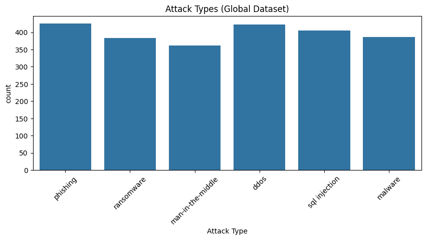

```python
global_sub.describe(include='all')
hack_sub.describe(include='all')

plt.figure(figsize=(10,4))
sns.countplot(data=global_sub, x='Attack Type')
plt.xticks(rotation=45)
plt.title("Attack Types (Global Dataset)")
plt.show()
```

# **Intepretation**

This graph gives us some insight to begin answering our question: What are the emerging technological security threats? We can see from the frequency counts that most attack types are pretty high ranging from 350 to 400. Phishing and ddos are the highest ones, which signals that attackers are frequently targeting vulnerabilities that can lead to serious operational, financial, and reputational harm. Effective defenses and awareness are crucial to mitigate these risks. Phishing explots human error, while DDoS exploits infrastructural weaknesses. This is what makes them persistent and damaging.

Phishing is when attackers impersonate legitimate entities (like banks or trusted companies) to trick individuals into revealing sensitive information. Whereas ddos or Distributed Denial of Service attacks slow down a target site/network by traffic jamming it.

# **Time-Series Trends**

Attacks per year across datasets.

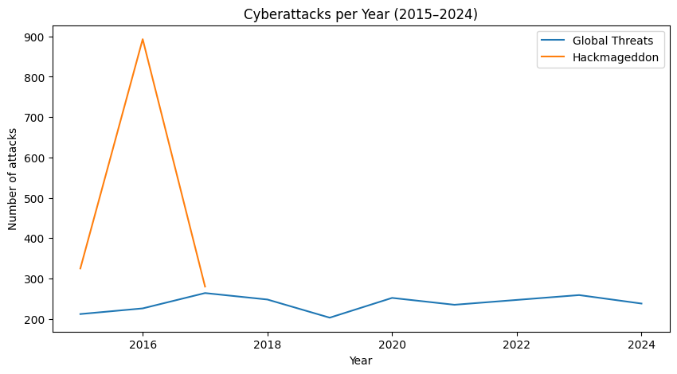

```python
ts1 = global_sub.groupby('Year').size()
ts2 = hack_sub.groupby('Year').size()

plt.figure(figsize=(10,5))
plt.plot(ts1.index, ts1.values, label="Global Threats")
plt.plot(ts2.index, ts2.values, label="Hackmageddon")
plt.legend()
plt.title("Cyberattacks per Year (2015–2024)")
plt.xlabel("Year")
plt.ylabel("Number of attacks")
plt.show()
```

# **Network Analysis**

```python
# Build graph
G = nx.from_pandas_edgelist(
    hack_sub,
    source='Author',
    target='Target',
    edge_attr='Attack_class',
    create_using=nx.DiGraph()
)

# Centrality
deg_cent = nx.degree_centrality(G)
bet_cent = nx.betweenness_centrality(G)

top_attackers = sorted(deg_cent.items(), key=lambda x: x[1], reverse=True)[:10]
top_attackers
```

```
[('?', 0.44966814159292035),
 ('anonymous', 0.0331858407079646),
 ('ourmine', 0.012721238938053096),
 ('kapustkiy', 0.00663716814159292),
 ('russia?', 0.00497787610619469),
 ('sonnyspooks', 0.00497787610619469),
 ('the dark overlord', 0.00497787610619469),
 ('poodlecorp', 0.004424778761061947),
 ('eggfather', 0.0027654867256637168),
 ('china', 0.0027654867256637168)]
```

# **Visualizing the Network**

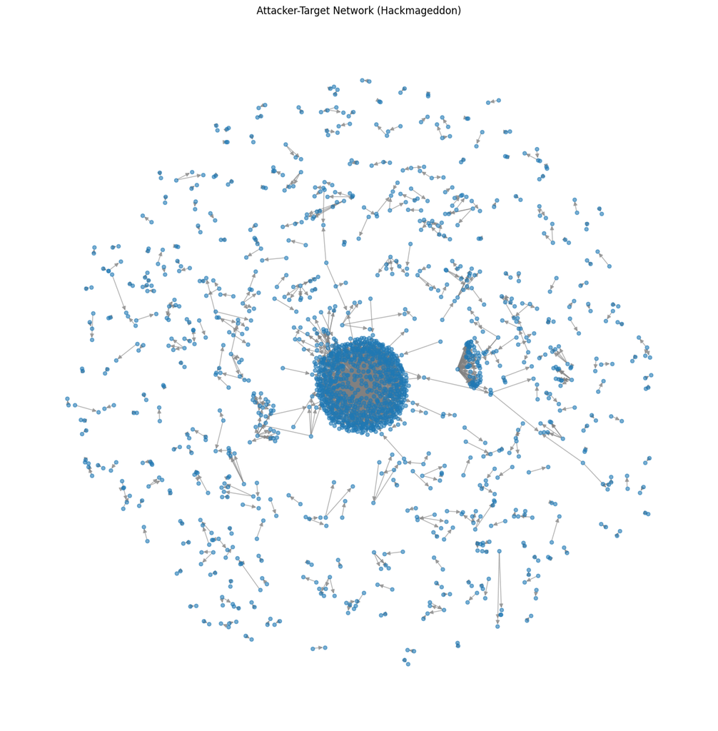

```python
plt.figure(figsize=(12,12))
pos = nx.spring_layout(G, k=0.25)
nx.draw(G, pos, node_size=20, alpha=0.6, edge_color='gray')
plt.title("Attacker-Target Network (Hackmageddon)")
plt.show()
```

# **Intepretation**

This network is very busy and dense. It has a big cluster of nodes in the middle which could imply that there are a lot of connected attackers/targets in the middle. The network has many small weakly connected groups as well (away from the central cluster), indicating cyberattacks occur both in isolated incidents and in larger campaigns/networks. From this network we cannot tell the geographic locations of each of our nodes. The location could provide more actionable insights about the network and also answer our second question, which is "Where should a cybersecurity investigative office be located to maximize effectiveness?